# Series de tiempo

# Base de datos cerditos

## Marco teorico: ¿Por qué los cerditos?

Tenga presente que el analisis del consumo carnico para una poblacion es importante pueto que a las entidades gubernamentales le permite controlar y entender dicho comportamiento para identificar y preveer posibles problemas de salud publica o en su defecto, generar politicas para controlar la economia del consumo. Se entiende pues, que un analisis para con el consumo es de vital importancia para los analisis demograficos de una poblacion.

Tambien, tener un control total sobre la cantidad de cerdos sacrificados, ayuda a las entidades sanitarias a mantener un estandar en dicha produccion. Si esto no es regulado, se pueden propagar enfermedadas por la mala praxis en la industria.

En el presente analisis, se desea predecir el numero total de cabezas porcinas sacrificadas.

## Procesamiento de la base de datos

El primer paso es la lectura de los datos. Note que los nombres de la serie se encuentran inapropiados para trabajar con ellos.

```r
df = read_delim("cerdos.csv",
    delim = ";", escape_double = FALSE, trim_ws = TRUE)
```

La variable año se convierte en ‘ano’. Nos gusta ese nombre entonces, asi se queda. Basicamente esta es la estructura de la base de datos. La cual, tiene las siguientes variables.

```r
df = clean_names(df)
df %>% names()
```

```
## [1] "ano"                         "mes"
## [3] "sacrificios_porcinos_machos" "sacrificio_porcinos_hembras"
## [5] "sacrificio_totales"          "latitud"
## [7] "longitud"
```

Descripcion de las variables en el dataframe:

*Ano:* Año en el que se toma el registro

*sacrificios_porcinos_machos:* El nombre lo indica, cantidad de sacrificios porcinos machos

```r
df$mes %>% unique() # Se verifica que no estén repetidos valores
```

```
##  [1] "Enero"      "Febrero"    "Marzo"      "Abril"      "Mayo"
##  [6] "Junio"      "Julio"      "Agosto"     "Septiembre" "Octubre"
## [11] "Noviembre"  "Diciembre"
```

Se procede entonces a crear la variable ‘date’ que representará la fecha asociada a cada dato.

```r
df$mes =as.factor(df$mes)
df$mes %>% levels# CUando se convierte en factor, cambia el orden
```

```
##  [1] "Abril"      "Agosto"     "Diciembre"  "Enero"      "Febrero"
##  [6] "Julio"      "Junio"      "Marzo"      "Mayo"       "Noviembre"
## [11] "Octubre"    "Septiembre"
```

```r
month_id = c(4,8,12,1,2,7,6,3,5,11,10,9)
levels(df$mes) = month_id
df$mes = df$mes %>% as.character()
```

Cuando se aplica la funcion as.factor, el orden de los mismos cambia. Entonces simplemente, se cambiará los niveles de la variable como factor a un valor numerico, siendo 1 enero, 2 febrero y asi sucesivamente. Luego, se transforma en string (Caracter) para obtener finalmente el mes en numero.

Para adquirir correctamente el formato en date, se ha de tener un dia cualquiera agregado. Se escoge el dia 13.

```r
df$dia = replicate(length(df$ano), '13')
df$ano = df$ano %>% as.character()

df$date = paste(df$dia,df$mes,df$ano,sep = '-')
df$date = as.Date(df$date, format = '%d-%m-%Y')
# Con esto, se tiene la base de datos lista para trabajar

df = df[order(df$date),] # ordenando por fecha mas vieja
```

## Total por Macho y Hembra

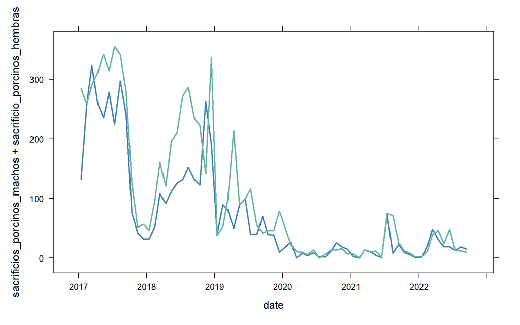

```r
xyplot(sacrificios_porcinos_machos+ sacrificio_porcinos_hembras ~ date, df, type = "l", col=c("steelblue", "#69b3a2") , lwd=2)
```

## Total de sacrificios porcinos

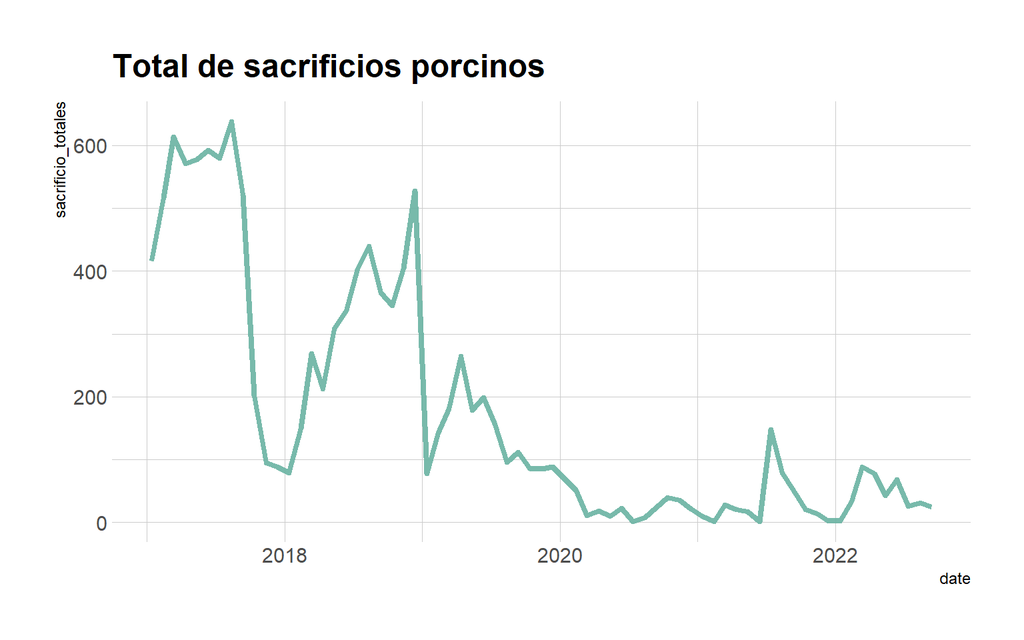

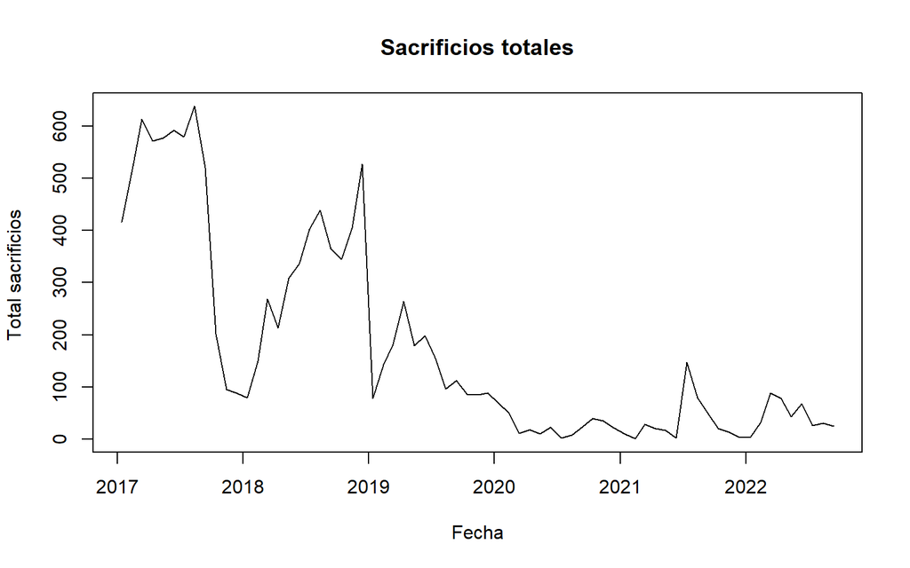

```r
plot(df$date, df$sacrificio_totales, type = 'l',main = 'Sacrificios totales',xlab = 'Fecha',ylab = 'Total sacrificios ')
```

```r
mod1 = auto.arima(df$sacrificio_totales)
summary(mod1)
```

```
## Series: df$sacrificio_totales
## ARIMA(0,1,0)
##
## sigma^2 = 7224:  log likelihood = -392.72
## AIC=787.45   AICc=787.51   BIC=789.65
##
## Training set error measures:
##                     ME     RMSE      MAE       MPE     MAPE      MASE
## Training set -5.743882 84.36956 48.34435 -66.38355 97.18585 0.9854188
##                     ACF1
## Training set -0.04235482
```

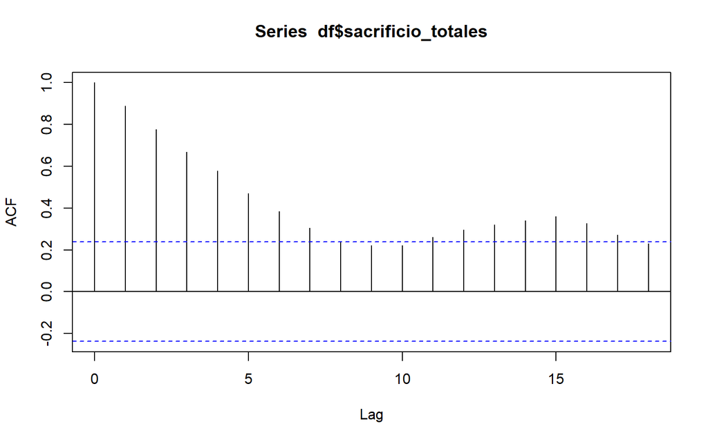

```r
acf(df$sacrificio_totales) # cae lento
```

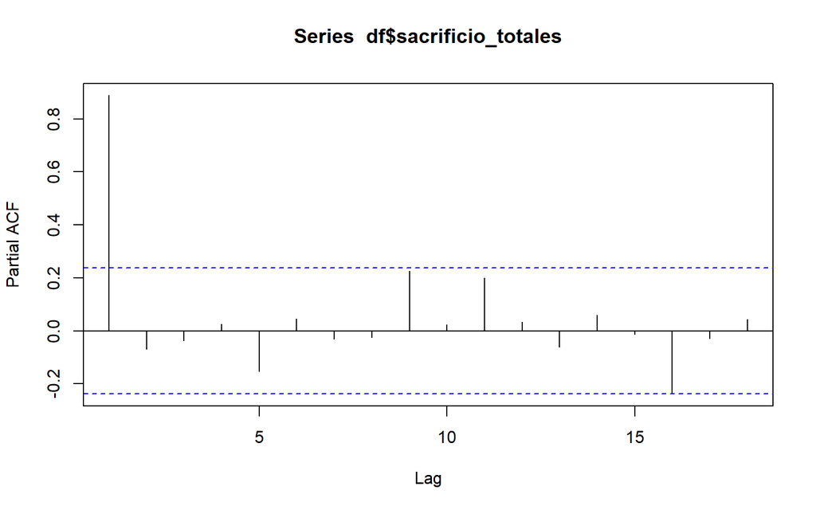

```r
pacf(df$sacrificio_totales) # ¿No es un buen problema?
```

```r
cerditos_2_la_venganza <- read_excel("cerditos 2 la venganza.xls",
    sheet = "Cuadro 3", skip = 9)
df2 =cerditos_2_la_venganza


df2 = cerditos_2_la_venganza
df2 = df %>% clean_names()
df2 %>% head(3)
```

```
## # A tibble: 3 × 9
##   ano   mes   sacrificios_porcinos_ma… sacrificio_porc… sacrificio_tota… latitud
##   <chr> <chr>                    <dbl>            <dbl>            <dbl>   <dbl>
## 1 2017  1                          132              284              416    52.6
## 2 2017  2                          258              259              517    52.6
## 3 2017  3                          323              290              613    52.6
## # … with 3 more variables: longitud <dbl>, dia <chr>, date <date>
```

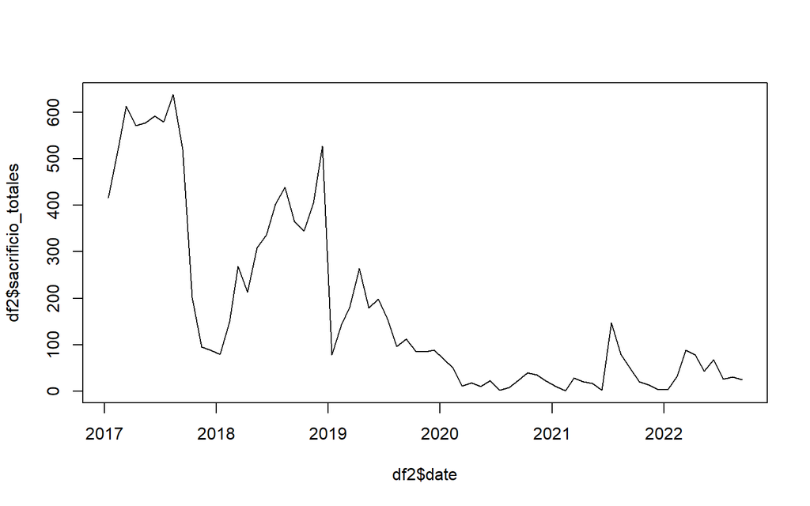

```r
plot(df2$date, df2$sacrificio_totales, 'l')
```

```r
a=df$sacrificio_totales
test = auto.arima(na.omit(a))
test
```

```
## Series: na.omit(a)
## ARIMA(0,1,0)
##
## sigma^2 = 7224:  log likelihood = -392.72
## AIC=787.45   AICc=787.51   BIC=789.65
```

# Base de datos nacimientos hospital

```r
# fn para calcular las raices unitarias y graficas bien chimbita
arroots <- function(object)
{
  if(!("Arima" %in% class(object)) &
     !("ar" %in% class(object)))
    stop("object must be of class Arima or ar")
  if("Arima" %in% class(object))
    parvec <- object$model$phi
  else
    parvec <- object$ar
  if(length(parvec) > 0)
  {
    last.nonzero <- max(which(abs(parvec) > 1e-08))
    if (last.nonzero > 0)
      return(structure(list(
          roots=polyroot(c(1,-parvec[1:last.nonzero])),
          type="AR"),
        class='armaroots'))
  }
  return(structure(list(roots=numeric(0), type="AR"),
    class='armaroots'))
}

# Compute MA roots
maroots <- function(object)
{
  if(!("Arima" %in% class(object)))
    stop("object must be of class Arima")
  parvec <- object$model$theta
  if(length(parvec) > 0)
  {
    last.nonzero <- max(which(abs(parvec) > 1e-08))
    if (last.nonzero > 0)
      return(structure(list(
          roots=polyroot(c(1,parvec[1:last.nonzero])),
          type="MA"),
        class='armaroots'))
  }
  return(structure(list(roots=numeric(0), type="MA"),
    class='armaroots'))
}

plot.armaroots <- function(x, xlab="Real", ylab="Imaginary",
    main=paste("Inverse roots of", x$type,
          "characteristic polynomial"),
    ...)
{
  oldpar <- par(pty='s')
  on.exit(par(oldpar))
  plot(c(-1,1), c(-1,1), xlab=xlab, ylab=ylab,
       type="n", bty="n", xaxt="n", yaxt="n", main=main, ...)
  axis(1, at=c(-1,0,1), line=0.5, tck=-0.025)
  axis(2, at=c(-1,0,1), label=c("-i","0","i"),
    line=0.5, tck=-0.025)
  circx <- seq(-1,1,l=501)
  circy <- sqrt(1-circx^2)
  lines(c(circx,circx), c(circy,-circy), col='gray')
  lines(c(-2,2), c(0,0), col='gray')
  lines(c(0,0), c(-2,2), col='gray')
  if(length(x$roots) > 0)
  {
    inside <- abs(x$roots) > 1
    points(1/x$roots[inside], pch=19, col='black')
    if(sum(!inside) > 0)
      points(1/x$roots[!inside], pch=19, col='red')
  }
}
```

Inicialmente se desea trabajar con un indice. Proporcion de niñas nacidas vs niños nacidos ; es decir:

Hembra/ macho; queremos ver si es igual, menor y si esto tiene una evolucion en el tiempo.

```r
datos <- read.csv("Nacidos_Vivos_en_Hospital_Manuel_Uribe_Angel.csv")
datos$FECHA.NACIMIENTO <- gsub(" \\d+:\\d+:\\d+ .*", "", datos$FECHA.NACIMIENTO)
datos$FECHA.NACIMIENTO <- as.Date(datos$FECHA.NACIMIENTO, format = "%m/%d/%Y")
```

```r
datos <- datos %>%
  mutate(Anio = year(FECHA.NACIMIENTO), semana = week(FECHA.NACIMIENTO)) %>%
  group_by(Anio, semana) %>%
  summarise(ratio = sum(SEXO != "MASCULINO")/sum(SEXO == "MASCULINO"))
lambda <- forecast::BoxCox.lambda(datos$ratio)
datos$ratio <- forecast::BoxCox(datos$ratio, lambda)
```

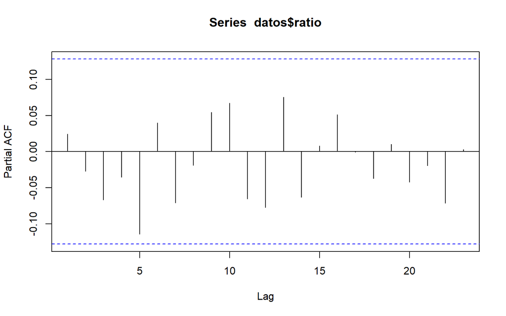

```r
pacf(datos$ratio)
```

Empezamos mal…

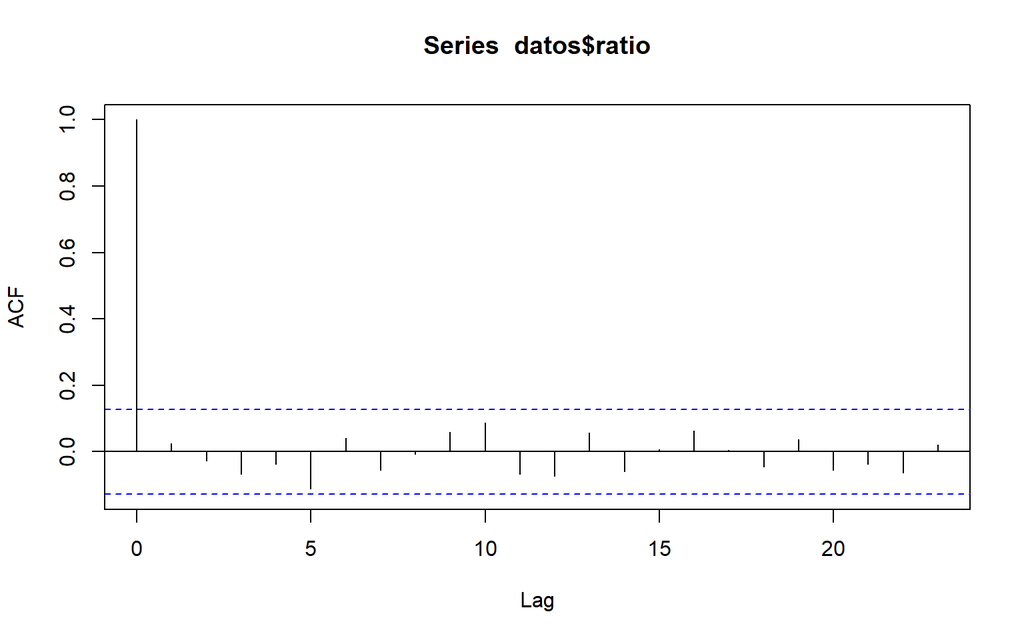

```r
acf(datos$ratio)
```

Y terminamos pior. Valemos verga.

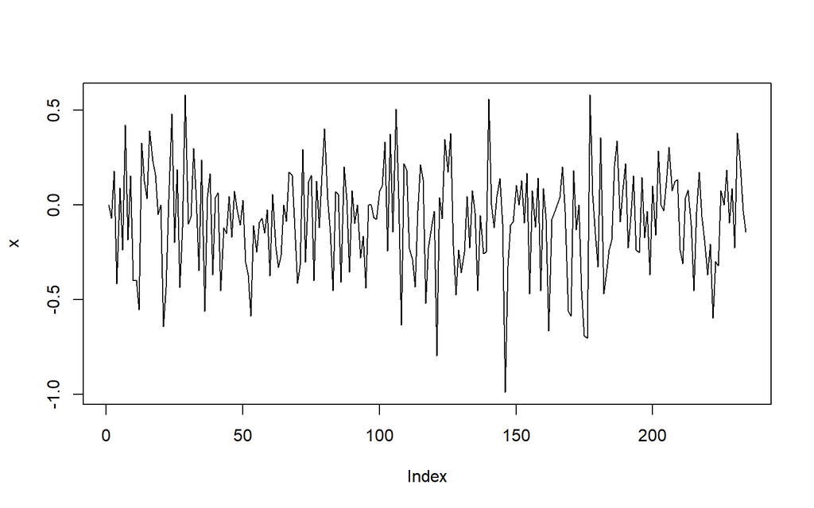

```r
x = datos$ratio
plot(x, type = "l")
```

Ombe pues bonita si se ve peeero… Y entonces?

```r
mod <- forecast::auto.arima(datos$ratio)
summary(mod)
```

```
## Series: datos$ratio
## ARIMA(0,0,0) with non-zero mean
##
## Coefficients:
##          mean
##       -0.0792
## s.e.   0.0176
##
## sigma^2 = 0.07244:  log likelihood = -24.4
## AIC=52.81   AICc=52.86   BIC=59.72
##
## Training set error measures:
##                         ME      RMSE       MAE  MPE MAPE      MASE       ACF1
## Training set -1.078795e-16 0.2685679 0.2123661 -Inf  Inf 0.7034017 0.02433439
```

Como dijo aquella figura de la tv mexicana; ‘Lo sospeché desde un principio’

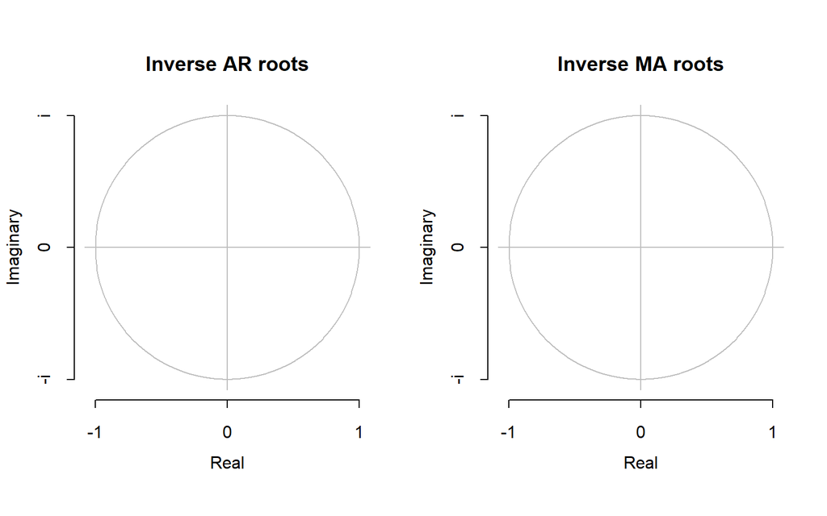

```r
library(forecast)
fit <- mod
par(mfrow=c(1,2))
plot(arroots(fit),main="Inverse AR roots")
plot(maroots(fit),main="Inverse MA roots")
```

Basicamente vale monda este modelo. No el modelo, el problema

¿Que pasó con las raíces? # Maso, oh tu que todo lo sabes. Iluminad a este pobre mortal, pues la luz de la esperanza se escapa ante cada linea de codigo que escribe.

Hipotesis: La naturaleza del problema no responde a un analisis de series temporales. La proporcion de nacimientos de niños vs niñas no varia en el tiempo; no es un dato temporal.

Nota para smith del futuro: Basicamente, piense en la teoria antes de perder toda la tarde haciendo estas pendejadas buscando soluciones rebuscadas. KISS

## Niños… Oh, si; niños.

```r
# Probemos con una bd de conteo de niños.
datos <- read.csv("Nacidos_Vivos_en_Hospital_Manuel_Uribe_Angel.csv")
datos$FECHA.NACIMIENTO <- gsub(" \\d+:\\d+:\\d+ .*", "", datos$FECHA.NACIMIENTO)
datos$FECHA.NACIMIENTO <- as.Date(datos$FECHA.NACIMIENTO, format = "%m/%d/%Y")
# otra veez, porque soy imbecil

datos.total.kids = datos[order(datos$FECHA.NACIMIENTO),]

datos.total.kids = datos.total.kids %>% mutate(Anio = year(FECHA.NACIMIENTO), semana = week(FECHA.NACIMIENTO)) %>%group_by(Anio, semana) %>%
  summarise(total.kids = sum(SEXO == 'MASCULINO')+sum(SEXO !='MASCULINO')  )
#Miremos que salió
```

Misma base de datos, ah verdad, no se la hemos mostrado al profesor. La base de datos. PROFE!

```r
datos %>% head() # Hay muchas variables.
```

```
##   DEPARTAMENTO MUNICIPIO    AREA.NACIMIENTO      SEXO PESO..Gramos.
## 1    ANTIOQUIA  ENVIGADO CABECERA MUNICIPAL MASCULINO          2085
## 2    ANTIOQUIA  ENVIGADO CABECERA MUNICIPAL  FEMENINO          3000
## 3    ANTIOQUIA  ENVIGADO CABECERA MUNICIPAL MASCULINO          2905
## 4    ANTIOQUIA  ENVIGADO CABECERA MUNICIPAL  FEMENINO          3700
## 5    ANTIOQUIA  ENVIGADO CABECERA MUNICIPAL  FEMENINO          3130
## 6    ANTIOQUIA  ENVIGADO CABECERA MUNICIPAL MASCULINO          3830
##   TALLA..Centímetros. FECHA.NACIMIENTO TIEMPO.DE.GESTACIÓN
## 1                  45       2022-05-06                  37
## 2                  47       2022-05-06                  37
## 3                  50       2022-05-07                  39
## 4                  50       2022-05-07                  40
## 5                  49       2022-05-07                  39
## 6                  54       2021-10-01                  40
##   NÚMERO.CONSULTAS.PRENATALES    TIPO.PARTO MULTIPLICIDAD.EMBARAZO
```

[output cut: 62 more lines]

Para este enfoque, interesa contar numero de machos que nacen,o de mujeres y analizar si hay un comportamiento en el timepo de los nacimientos.

Dicho de otra manera, si hay una estacionalidad en una fecha; implica entonces que nueve meses antes se encuentran los mas culiones.

*Podriamos dictaminar, los signos zodiacales mas promiscuos? Donde estan las perras? Les leemos el Tarot con un modelo ARIMA?*

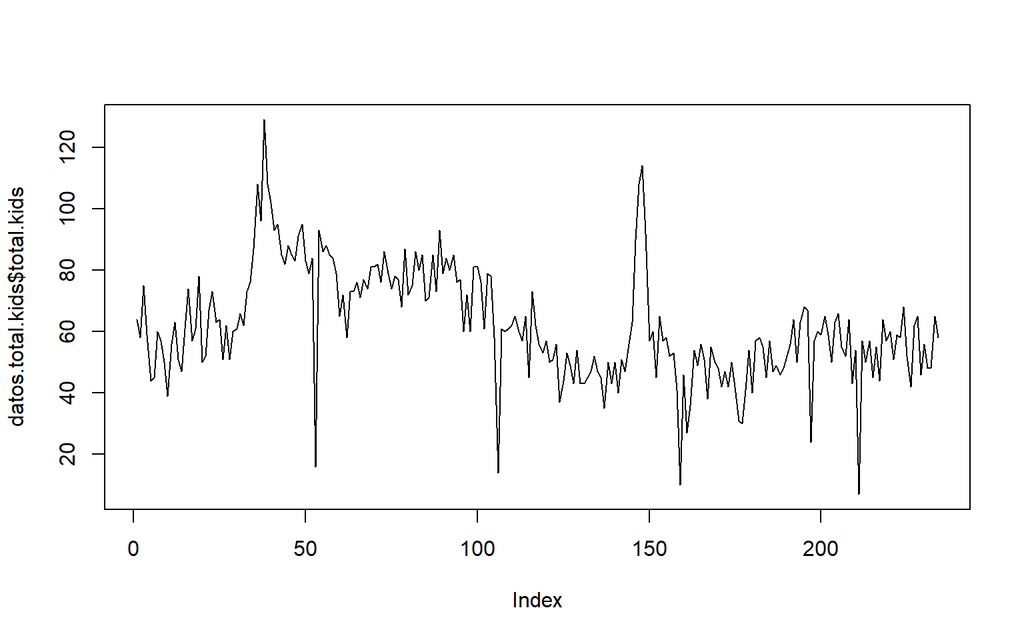

```r
plot(datos.total.kids$total.kids, type = 'l') # se ve mas chimbita
```

```r
b=auto.arima(datos.total.kids$total.kids) # tiene mas sentido
b
```

```
## Series: datos.total.kids$total.kids
## ARIMA(1,1,2)
##
## Coefficients:
##          ar1      ma1     ma2
##       0.8278  -1.4003  0.4234
## s.e.  0.1064   0.1326  0.1124
##
## sigma^2 = 164.3:  log likelihood = -923.88
## AIC=1855.75   AICc=1855.93   BIC=1869.56
```

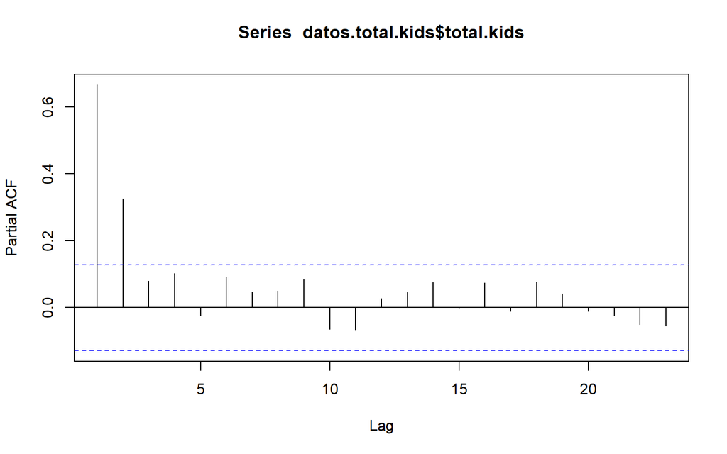

```r
pacf(datos.total.kids$total.kids)
```

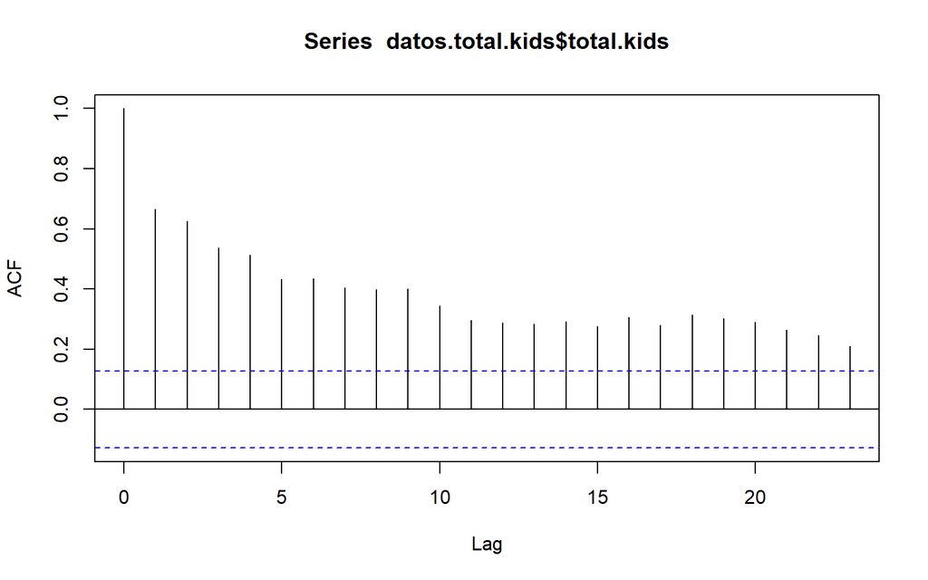

```r
acf(datos.total.kids$total.kids)
```

Si señor. Este modelo tiene mas sentido. Puesto que la naturaleza del problema TIENE mas sentido. No como la pinche proporcion. Muy bien SMith, a este paso; cuando grande serás como Mazo.

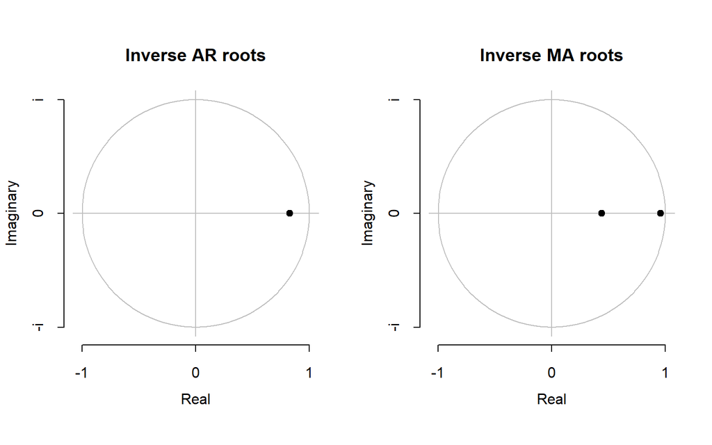

```r
fit <- b
par(mfrow=c(1,2))
plot(arroots(fit),main="Inverse AR roots")
plot(maroots(fit),main="Inverse MA roots")
```

remember: (And as a consequence, the solution of a homogeneous autoregressive difference equation is stable if all roots of its characteristic polynomials are inside the unit circle, or equivalently, the roots of its inverse characteristic polynomial are outside of the unit circle.)

Mas melo para donde?